# Jennifer Hightower

## Supervised Learning Regression Project: Cars4U

Data Dictionary

S.No.: Serial number

Name: Name of the car which includes brand name and model name

Location: Location in which the car is being sold or is available for purchase (cities)

Year: Manufacturing year of the car

Kilometers_driven: The total kilometers (a unit used to measure length or distance) driven in the car by the previous owner(s)

Fuel_Type: The type of fuel used by the car (Petrol, Diesel, Electric, CNG, LPG)

Transmission: The type of transmission used by the car (Automatic/Manual)

Owner: Type of ownership

Mileage: The standard mileage offered by the car company in kmpl or km/kg

Engine: The displacement volume of the engine in CC

Power: The maximum power of the engine in bhp

Seats: The number of seats in the car

New_Price: The price of a new car of the same model in INR Lakhs (1 Lakh INR = 100,000 INR)

Price: The price of the used car in INR Lakhs

```python
import warnings
warnings.filterwarnings('ignore')
import pandas as pd #library for data manipulation and analysis
import numpy as np #library used for working with arrays
import matplotlib.pyplot as plt #library for plots and visualizations
import seaborn as sns #library for visualizations
from scipy.stats import norm #using normal distibutions
from scipy.stats import zscore

#Linear Regression
from sklearn.linear_model import LinearRegression
from sklearn.model_selection import train_test_split # Sklearn package's randomized data splitting function

%matplotlib inline

pd.set_option('display.float_format', lambda x: '%.2f' % x) # To supress numerical display in scientific notations


import scipy.stats #library contains a number of probibility distributions and statistical functions

df = pd.read_csv('used_cars_data.csv')




#Quick Basic Checks
df.head()
```

|  | S.No. | Name | Location | Year | Kilometers_Driven | Fuel_Type | Transmission | Owner_Type | Mileage | Engine | Power | Seats | New_Price | Price |
| --- | --- | --- | --- | --- | --- | --- | --- | --- | --- | --- | --- | --- | --- | --- |
| 0 | 0 | Maruti Wagon R LXI CNG | Mumbai | 2010 | 72000 | CNG | Manual | First | 26.6 km/kg | 998 CC | 58.16 bhp | 5.00 | 5.51 | 1.75 |
| 1 | 1 | Hyundai Creta 1.6 CRDi SX Option | Pune | 2015 | 41000 | Diesel | Manual | First | 19.67 kmpl | 1582 CC | 126.2 bhp | 5.00 | 16.06 | 12.50 |
| 2 | 2 | Honda Jazz V | Chennai | 2011 | 46000 | Petrol | Manual | First | 18.2 kmpl | 1199 CC | 88.7 bhp | 5.00 | 8.61 | 4.50 |
| 3 | 3 | Maruti Ertiga VDI | Chennai | 2012 | 87000 | Diesel | Manual | First | 20.77 kmpl | 1248 CC | 88.76 bhp | 7.00 | 11.27 | 6.00 |
| 4 | 4 | Audi A4 New 2.0 TDI Multitronic | Coimbatore | 2013 | 40670 | Diesel | Automatic | Second | 15.2 kmpl | 1968 CC | 140.8 bhp | 5.00 | 53.14 | 17.74 |

```python
df.info()
```

```
<class 'pandas.core.frame.DataFrame'>
RangeIndex: 7253 entries, 0 to 7252
Data columns (total 14 columns):
 #   Column             Non-Null Count  Dtype
---  ------             --------------  -----
 0   S.No.              7253 non-null   int64
 1   Name               7253 non-null   object
 2   Location           7253 non-null   object
 3   Year               7253 non-null   int64
 4   Kilometers_Driven  7253 non-null   int64
 5   Fuel_Type          7253 non-null   object
 6   Transmission       7253 non-null   object
 7   Owner_Type         7253 non-null   object
 8   Mileage            7251 non-null   object
 9   Engine             7207 non-null   object
 10  Power              7078 non-null   object
 11  Seats              7200 non-null   float64
 12  New_Price          7253 non-null   float64
 13  Price              6019 non-null   float64
dtypes: float64(3), int64(3), object(8)
memory usage: 793.4+ KB
```

```python
#doing a quick check for duplicates
df.duplicated().sum()
```

```
0
```

```python
df.Name.unique()
```

```
array(['Maruti Wagon R LXI CNG', 'Hyundai Creta 1.6 CRDi SX Option',
       'Honda Jazz V', ..., 'Ford EcoSport 1.5 Petrol Ambiente',
       'Jeep Compass 1.4 Sport', 'Hyundai Elite i20 Magna Plus'],
      dtype=object)
```

```python
df.Name.nunique()
```

```
2041
```

So the Name column will need to be cleaned up. 2041 unique values will not work. The Name description looks like it contains the makes, model and details about the car.

```python
# split each string at the first space character and extract the first element
df['Car_Make'] = df.Name.str.split(' ').str[0].apply(lambda x: x.upper())

df.head()
```

|  | S.No. | Name | Location | Year | Kilometers_Driven | Fuel_Type | Transmission | Owner_Type | Mileage | Engine | Power | Seats | New_Price | Price | Car_Make |
| --- | --- | --- | --- | --- | --- | --- | --- | --- | --- | --- | --- | --- | --- | --- | --- |
| 0 | 0 | Maruti Wagon R LXI CNG | Mumbai | 2010 | 72000 | CNG | Manual | First | 26.6 km/kg | 998 CC | 58.16 bhp | 5.00 | 5.51 | 1.75 | MARUTI |
| 1 | 1 | Hyundai Creta 1.6 CRDi SX Option | Pune | 2015 | 41000 | Diesel | Manual | First | 19.67 kmpl | 1582 CC | 126.2 bhp | 5.00 | 16.06 | 12.50 | HYUNDAI |
| 2 | 2 | Honda Jazz V | Chennai | 2011 | 46000 | Petrol | Manual | First | 18.2 kmpl | 1199 CC | 88.7 bhp | 5.00 | 8.61 | 4.50 | HONDA |
| 3 | 3 | Maruti Ertiga VDI | Chennai | 2012 | 87000 | Diesel | Manual | First | 20.77 kmpl | 1248 CC | 88.76 bhp | 7.00 | 11.27 | 6.00 | MARUTI |
| 4 | 4 | Audi A4 New 2.0 TDI Multitronic | Coimbatore | 2013 | 40670 | Diesel | Automatic | Second | 15.2 kmpl | 1968 CC | 140.8 bhp | 5.00 | 53.14 | 17.74 | AUDI |

```python
df.drop(['Name'],axis=1,inplace=True)
df.head()
```

|  | S.No. | Location | Year | Kilometers_Driven | Fuel_Type | Transmission | Owner_Type | Mileage | Engine | Power | Seats | New_Price | Price | Car_Make |
| --- | --- | --- | --- | --- | --- | --- | --- | --- | --- | --- | --- | --- | --- | --- |
| 0 | 0 | Mumbai | 2010 | 72000 | CNG | Manual | First | 26.6 km/kg | 998 CC | 58.16 bhp | 5.00 | 5.51 | 1.75 | MARUTI |
| 1 | 1 | Pune | 2015 | 41000 | Diesel | Manual | First | 19.67 kmpl | 1582 CC | 126.2 bhp | 5.00 | 16.06 | 12.50 | HYUNDAI |
| 2 | 2 | Chennai | 2011 | 46000 | Petrol | Manual | First | 18.2 kmpl | 1199 CC | 88.7 bhp | 5.00 | 8.61 | 4.50 | HONDA |
| 3 | 3 | Chennai | 2012 | 87000 | Diesel | Manual | First | 20.77 kmpl | 1248 CC | 88.76 bhp | 7.00 | 11.27 | 6.00 | MARUTI |
| 4 | 4 | Coimbatore | 2013 | 40670 | Diesel | Automatic | Second | 15.2 kmpl | 1968 CC | 140.8 bhp | 5.00 | 53.14 | 17.74 | AUDI |

```python
df.Car_Make.unique()
```

```
array(['MARUTI', 'HYUNDAI', 'HONDA', 'AUDI', 'NISSAN', 'TOYOTA',
       'VOLKSWAGEN', 'TATA', 'LAND', 'MITSUBISHI', 'RENAULT',
       'MERCEDES-BENZ', 'BMW', 'MAHINDRA', 'FORD', 'PORSCHE', 'DATSUN',
       'JAGUAR', 'VOLVO', 'CHEVROLET', 'SKODA', 'MINI', 'FIAT', 'JEEP',
       'SMART', 'AMBASSADOR', 'ISUZU', 'FORCE', 'BENTLEY', 'LAMBORGHINI',
       'HINDUSTAN', 'OPELCORSA'], dtype=object)
```

```python
df.Car_Make.nunique()
```

```
32
```

### Already I can see that columns Mileage, Engine and Power will nead to be cleaned and transformed.

1. Mileage - I will convert the kmpl and km.kg to mpg just to make things consistent and change the datatype to float
2. Engine - I will remove the CC and change the datatype to int
3. Power - I will remove the bhp and convert the datatype to float

```python
#Split Mileage on space to split the text and integers into seperate columns



# split the Mileage column into two columns
df = df.assign(Mileage_unit=df["Mileage"].str.split(" ", n=1, expand=True)[1], Mileage_value=df["Mileage"].str.split(" ", n=1, expand=True)[0])
# split the Engine column into two columns
df = df.assign(Engine_unit=df["Engine"].str.split(" ", n=1, expand=True)[1], Engine_value=df["Engine"].str.split(" ", n=1, expand=True)[0])
# split the Power column into two columns
df = df.assign(Power_unit=df["Power"].str.split(" ", n=1, expand=True)[1], Power_value=df["Power"].str.split(" ", n=1, expand=True)[0])



# drop the original Mileage column
df = df.drop(['Mileage', 'Engine', 'Power'], axis=1)

# print the resulting dataframe
df.head()
```

|  | S.No. | Location | Year | Kilometers_Driven | Fuel_Type | Transmission | Owner_Type | Seats | New_Price | Price | Car_Make | Mileage_unit | Mileage_value | Engine_unit | Engine_value | Power_unit | Power_value |
| --- | --- | --- | --- | --- | --- | --- | --- | --- | --- | --- | --- | --- | --- | --- | --- | --- | --- |
| 0 | 0 | Mumbai | 2010 | 72000 | CNG | Manual | First | 5.00 | 5.51 | 1.75 | MARUTI | km/kg | 26.6 | CC | 998 | bhp | 58.16 |
| 1 | 1 | Pune | 2015 | 41000 | Diesel | Manual | First | 5.00 | 16.06 | 12.50 | HYUNDAI | kmpl | 19.67 | CC | 1582 | bhp | 126.2 |
| 2 | 2 | Chennai | 2011 | 46000 | Petrol | Manual | First | 5.00 | 8.61 | 4.50 | HONDA | kmpl | 18.2 | CC | 1199 | bhp | 88.7 |
| 3 | 3 | Chennai | 2012 | 87000 | Diesel | Manual | First | 7.00 | 11.27 | 6.00 | MARUTI | kmpl | 20.77 | CC | 1248 | bhp | 88.76 |
| 4 | 4 | Coimbatore | 2013 | 40670 | Diesel | Automatic | Second | 5.00 | 53.14 | 17.74 | AUDI | kmpl | 15.2 | CC | 1968 | bhp | 140.8 |

Sanity checking to make sure all the unique values in the mileage_unit column before I move forward with transforming the data to make sure I'm not missing anything

```python
df.Mileage_unit.unique()

#We have nan values, which I'm suprised by.  I want to see what those are
```

```
array(['km/kg', 'kmpl', nan], dtype=object)
```

```python
df.loc[df['Mileage_unit'].isnull()==True]
```

|  | S.No. | Location | Year | Kilometers_Driven | Fuel_Type | Transmission | Owner_Type | Seats | New_Price | Price | Car_Make | Mileage_unit | Mileage_value | Engine_unit | Engine_value | Power_unit | Power_value |
| --- | --- | --- | --- | --- | --- | --- | --- | --- | --- | --- | --- | --- | --- | --- | --- | --- | --- |
| 4446 | 4446 | Chennai | 2016 | 50000 | Electric | Automatic | First | 5.00 | 13.58 | 13.00 | MAHINDRA | NaN | NaN | CC | 72 | bhp | 41 |
| 4904 | 4904 | Mumbai | 2011 | 44000 | Electric | Automatic | First | 5.00 | 24.01 | 12.75 | TOYOTA | NaN | NaN | CC | 1798 | bhp | 73 |

Ah, these are electric cars, so they don't use gas. So if I will make a special conditional when the Fuel_Type is electric and the Mileage_unit is null then set the Mileage_value to 0, since they don't use gas.

```python
#testing my theory to make sure the logic is correct.  If it is then only S.NO 446 and 4904 will be returned

for index, row in df.iterrows():
    if (row['Fuel_Type'] == 'Electric') and pd.isnull(row['Mileage_value']):
        print(row['S.No.'])
```

```
4446
4904
```

The logic checks out, so I'm ready to transform the Mileage data

```python
df.loc[(df['Fuel_Type'] == 'Electric') & (df['Mileage_value'].isnull()), 'Mileage_value'] = 0

df.loc[df['Mileage_value'].isnull()==True]
```

|  | S.No. | Location | Year | Kilometers_Driven | Fuel_Type | Transmission | Owner_Type | Seats | New_Price | Price | Car_Make | Mileage_unit | Mileage_value | Engine_unit | Engine_value | Power_unit | Power_value |
| --- | --- | --- | --- | --- | --- | --- | --- | --- | --- | --- | --- | --- | --- | --- | --- | --- | --- |

```python
df['Mileage_value'] = df['Mileage_value'].astype(float)

df.info()
```

```
<class 'pandas.core.frame.DataFrame'>
RangeIndex: 7253 entries, 0 to 7252
Data columns (total 17 columns):
 #   Column             Non-Null Count  Dtype
---  ------             --------------  -----
 0   S.No.              7253 non-null   int64
 1   Location           7253 non-null   object
 2   Year               7253 non-null   int64
 3   Kilometers_Driven  7253 non-null   int64
 4   Fuel_Type          7253 non-null   object
 5   Transmission       7253 non-null   object
 6   Owner_Type         7253 non-null   object
 7   Seats              7200 non-null   float64
 8   New_Price          7253 non-null   float64
 9   Price              6019 non-null   float64
 10  Car_Make           7253 non-null   object
 11  Mileage_unit       7251 non-null   object
 12  Mileage_value      7253 non-null   float64
 13  Engine_unit        7207 non-null   object
 14  Engine_value       7207 non-null   object
 15  Power_unit         7078 non-null   object
 16  Power_value        7078 non-null   object
dtypes: float64(4), int64(3), object(10)
memory usage: 963.4+ KB
```

```python
#This is a sanity ceck, I want to make sure there are no objects in Mileage_value

num_to_display = 10  #
for i in df.dtypes[df.dtypes == 'object'].index:
    val_counts = df[i].value_counts(dropna=False)  # i want to see NA counts
    print(val_counts[:num_to_display])
    if len(val_counts) > num_to_display:
        print(f'Only displaying first {num_to_display} of {len(val_counts)} values.')
    print('\n\n') # just for more space between
```

```
Mumbai        949
Hyderabad     876
Coimbatore    772
Kochi         772
Pune          765
Delhi         660
Kolkata       654
Chennai       591
Jaipur        499
Bangalore     440
Name: Location, dtype: int64
Only displaying first 10 of 11 values.



Diesel      3852
Petrol      3325
CNG           62
LPG           12
Electric       2
Name: Fuel_Type, dtype: int64



Manual       5204
Automatic    2049
Name: Transmission, dtype: int64



First             5952
Second            1152
Third              137
Fourth & Above      12
Name: Owner_Type, dtype: int64



MARUTI           1444
HYUNDAI          1340
```

[output cut: 44 more lines]

```



74       280
NaN      175
98.6     166
73.9     152
140      142
78.9     128
67.1     126
67.04    125
82       124
88.5     120
Name: Power_value, dtype: int64
Only displaying first 10 of 386 values.
```

```python
# km/kg to kmpl conversion
def kmpl(km_per_kg, density):
    kmpl = km_per_kg / density
    return kmpl

# kmpl to mpg conversion
def kmpl_to_mpg(kmpl):
    mpg = kmpl * 2.35214583
    return mpg


# km/kg to mpg conversion
def km_to_mpg(km_per_kg):
    mpg = km_per_kg * 2.82481
    return mpg

# apply conversion functions using apply method
df.loc[df['Mileage_unit'] == 'kmpl', 'Mileage_value'] = df.loc[df['Mileage_unit'] == 'kmpl', 'Mileage_value'].apply(lambda x: kmpl_to_mpg(x))
df.loc[df['Mileage_unit'] == 'km/kg', 'Mileage_value'] = df.loc[df['Mileage_unit'] == 'km/kg', 'Mileage_value'].apply(lambda x: km_to_mpg(x))


df.head()
```

|  | S.No. | Location | Year | Kilometers_Driven | Fuel_Type | Transmission | Owner_Type | Seats | New_Price | Price | Car_Make | Mileage_unit | Mileage_value | Engine_unit | Engine_value | Power_unit | Power_value |
| --- | --- | --- | --- | --- | --- | --- | --- | --- | --- | --- | --- | --- | --- | --- | --- | --- | --- |
| 0 | 0 | Mumbai | 2010 | 72000 | CNG | Manual | First | 5.00 | 5.51 | 1.75 | MARUTI | km/kg | 75.14 | CC | 998 | bhp | 58.16 |
| 1 | 1 | Pune | 2015 | 41000 | Diesel | Manual | First | 5.00 | 16.06 | 12.50 | HYUNDAI | kmpl | 46.27 | CC | 1582 | bhp | 126.2 |
| 2 | 2 | Chennai | 2011 | 46000 | Petrol | Manual | First | 5.00 | 8.61 | 4.50 | HONDA | kmpl | 42.81 | CC | 1199 | bhp | 88.7 |
| 3 | 3 | Chennai | 2012 | 87000 | Diesel | Manual | First | 7.00 | 11.27 | 6.00 | MARUTI | kmpl | 48.85 | CC | 1248 | bhp | 88.76 |
| 4 | 4 | Coimbatore | 2013 | 40670 | Diesel | Automatic | Second | 5.00 | 53.14 | 17.74 | AUDI | kmpl | 35.75 | CC | 1968 | bhp | 140.8 |

```python
df['Mileage'] = df['Mileage_value']
df.drop(['Mileage_value', 'Mileage_unit'],axis=1,inplace=True)

df.info()
```

```
<class 'pandas.core.frame.DataFrame'>
RangeIndex: 7253 entries, 0 to 7252
Data columns (total 16 columns):
 #   Column             Non-Null Count  Dtype
---  ------             --------------  -----
 0   S.No.              7253 non-null   int64
 1   Location           7253 non-null   object
 2   Year               7253 non-null   int64
 3   Kilometers_Driven  7253 non-null   int64
 4   Fuel_Type          7253 non-null   object
 5   Transmission       7253 non-null   object
 6   Owner_Type         7253 non-null   object
 7   Seats              7200 non-null   float64
 8   New_Price          7253 non-null   float64
 9   Price              6019 non-null   float64
 10  Car_Make           7253 non-null   object
 11  Engine_unit        7207 non-null   object
 12  Engine_value       7207 non-null   object
 13  Power_unit         7078 non-null   object
 14  Power_value        7078 non-null   object
 15  Mileage            7253 non-null   float64
dtypes: float64(4), int64(3), object(9)
memory usage: 906.8+ KB
```

```python
df.Engine_unit.unique()
```

```
array(['CC', nan], dtype=object)
```

```python
df['Engine'] = df['Engine_value'].astype(float)
df.drop(['Engine_unit', 'Engine_value'],axis=1,inplace=True)
df.info()
```

```
<class 'pandas.core.frame.DataFrame'>
RangeIndex: 7253 entries, 0 to 7252
Data columns (total 15 columns):
 #   Column             Non-Null Count  Dtype
---  ------             --------------  -----
 0   S.No.              7253 non-null   int64
 1   Location           7253 non-null   object
 2   Year               7253 non-null   int64
 3   Kilometers_Driven  7253 non-null   int64
 4   Fuel_Type          7253 non-null   object
 5   Transmission       7253 non-null   object
 6   Owner_Type         7253 non-null   object
 7   Seats              7200 non-null   float64
 8   New_Price          7253 non-null   float64
 9   Price              6019 non-null   float64
 10  Car_Make           7253 non-null   object
 11  Power_unit         7078 non-null   object
 12  Power_value        7078 non-null   object
 13  Mileage            7253 non-null   float64
 14  Engine             7207 non-null   float64
dtypes: float64(5), int64(3), object(7)
memory usage: 850.1+ KB
```

```python
df.Power_unit.unique()
```

```
array(['bhp', nan], dtype=object)
```

```python
df['Power'] = df['Power_value'].astype(float)
df.drop(['Power_unit', 'Power_value'],axis=1,inplace=True)
df.info()
```

```
<class 'pandas.core.frame.DataFrame'>
RangeIndex: 7253 entries, 0 to 7252
Data columns (total 14 columns):
 #   Column             Non-Null Count  Dtype
---  ------             --------------  -----
 0   S.No.              7253 non-null   int64
 1   Location           7253 non-null   object
 2   Year               7253 non-null   int64
 3   Kilometers_Driven  7253 non-null   int64
 4   Fuel_Type          7253 non-null   object
 5   Transmission       7253 non-null   object
 6   Owner_Type         7253 non-null   object
 7   Seats              7200 non-null   float64
 8   New_Price          7253 non-null   float64
 9   Price              6019 non-null   float64
 10  Car_Make           7253 non-null   object
 11  Mileage            7253 non-null   float64
 12  Engine             7207 non-null   float64
 13  Power              7078 non-null   float64
dtypes: float64(6), int64(3), object(5)
memory usage: 793.4+ KB
```

```python
df.head()
```

|  | S.No. | Location | Year | Kilometers_Driven | Fuel_Type | Transmission | Owner_Type | Seats | New_Price | Price | Car_Make | Mileage | Engine | Power |
| --- | --- | --- | --- | --- | --- | --- | --- | --- | --- | --- | --- | --- | --- | --- |
| 0 | 0 | Mumbai | 2010 | 72000 | CNG | Manual | First | 5.00 | 5.51 | 1.75 | MARUTI | 75.14 | 998.00 | 58.16 |
| 1 | 1 | Pune | 2015 | 41000 | Diesel | Manual | First | 5.00 | 16.06 | 12.50 | HYUNDAI | 46.27 | 1582.00 | 126.20 |
| 2 | 2 | Chennai | 2011 | 46000 | Petrol | Manual | First | 5.00 | 8.61 | 4.50 | HONDA | 42.81 | 1199.00 | 88.70 |
| 3 | 3 | Chennai | 2012 | 87000 | Diesel | Manual | First | 7.00 | 11.27 | 6.00 | MARUTI | 48.85 | 1248.00 | 88.76 |
| 4 | 4 | Coimbatore | 2013 | 40670 | Diesel | Automatic | Second | 5.00 | 53.14 | 17.74 | AUDI | 35.75 | 1968.00 | 140.80 |

```python
#Dropping the  S.No. column because we won't need it

df.drop(['S.No.'],axis=1,inplace=True)
df.head()
```

|  | Location | Year | Kilometers_Driven | Fuel_Type | Transmission | Owner_Type | Seats | New_Price | Price | Car_Make | Mileage | Engine | Power |
| --- | --- | --- | --- | --- | --- | --- | --- | --- | --- | --- | --- | --- | --- |
| 0 | Mumbai | 2010 | 72000 | CNG | Manual | First | 5.00 | 5.51 | 1.75 | MARUTI | 75.14 | 998.00 | 58.16 |
| 1 | Pune | 2015 | 41000 | Diesel | Manual | First | 5.00 | 16.06 | 12.50 | HYUNDAI | 46.27 | 1582.00 | 126.20 |
| 2 | Chennai | 2011 | 46000 | Petrol | Manual | First | 5.00 | 8.61 | 4.50 | HONDA | 42.81 | 1199.00 | 88.70 |
| 3 | Chennai | 2012 | 87000 | Diesel | Manual | First | 7.00 | 11.27 | 6.00 | MARUTI | 48.85 | 1248.00 | 88.76 |
| 4 | Coimbatore | 2013 | 40670 | Diesel | Automatic | Second | 5.00 | 53.14 | 17.74 | AUDI | 35.75 | 1968.00 | 140.80 |

```python
df.Owner_Type.unique()
#I'm not sure what use this comun will be, but will keep it for now just incase it has value
```

```
array(['First', 'Second', 'Fourth & Above', 'Third'], dtype=object)
```

```python
#category
#convert categorical variables to categories
cat_vars = ['Location', 'Fuel_Type', 'Transmission',
            'Owner_Type', 'Car_Make']
# the other categorical variables have lots of levels
# and I wouldn't dummy encode them as such

for colname in cat_vars:
    df[colname] = df[colname].astype('category')

df.info()
```

```
<class 'pandas.core.frame.DataFrame'>
RangeIndex: 7253 entries, 0 to 7252
Data columns (total 13 columns):
 #   Column             Non-Null Count  Dtype
---  ------             --------------  -----
 0   Location           7253 non-null   category
 1   Year               7253 non-null   int64
 2   Kilometers_Driven  7253 non-null   int64
 3   Fuel_Type          7253 non-null   category
 4   Transmission       7253 non-null   category
 5   Owner_Type         7253 non-null   category
 6   Seats              7200 non-null   float64
 7   New_Price          7253 non-null   float64
 8   Price              6019 non-null   float64
 9   Car_Make           7253 non-null   category
 10  Mileage            7253 non-null   float64
 11  Engine             7207 non-null   float64
 12  Power              7078 non-null   float64
dtypes: category(5), float64(6), int64(2)
memory usage: 491.1 KB
```

```python
df.isnull().sum().sort_values(ascending=False)
```

```
Price                1234
Power                 175
Seats                  53
Engine                 46
Location                0
Year                    0
Kilometers_Driven       0
Fuel_Type               0
Transmission            0
Owner_Type              0
New_Price               0
Car_Make                0
Mileage                 0
dtype: int64
```

We still have null values in Price, Power, Seats and Engine that we need to treat

Price might be and issue since 17% of the data is null

```python
pd.DataFrame({'Count':df.isnull().sum()[df.isnull().sum()>0],'Percentage':(df.isnull().sum()[df.isnull().sum()>0]/df.shape[0])*100})
```

|  | Count | Percentage |
| --- | --- | --- |
| Seats | 53 | 0.73 |
| Price | 1234 | 17.01 |
| Engine | 46 | 0.63 |
| Power | 175 | 2.41 |

```python
df.loc[df['Price'].isnull()==True]
```

|  | Location | Year | Kilometers_Driven | Fuel_Type | Transmission | Owner_Type | Seats | New_Price | Price | Car_Make | Mileage | Engine | Power |
| --- | --- | --- | --- | --- | --- | --- | --- | --- | --- | --- | --- | --- | --- |
| 6019 | Delhi | 2014 | 40929 | CNG | Manual | First | 4.00 | 4.36 | NaN | MARUTI | 91.13 | 998.00 | 58.20 |
| 6020 | Coimbatore | 2013 | 54493 | Petrol | Manual | Second | 5.00 | 4.36 | NaN | MARUTI | 58.10 | 796.00 | 47.30 |
| 6021 | Mumbai | 2017 | 34000 | Diesel | Manual | First | 7.00 | 25.27 | NaN | TOYOTA | 32.18 | 2393.00 | 147.80 |
| 6022 | Hyderabad | 2012 | 139000 | Diesel | Manual | First | 5.00 | 8.53 | NaN | TOYOTA | 55.49 | 1364.00 | NaN |
| 6023 | Mumbai | 2014 | 29000 | Petrol | Manual | First | 5.00 | 10.25 | NaN | HYUNDAI | 43.51 | 1197.00 | 82.85 |
| ... | ... | ... | ... | ... | ... | ... | ... | ... | ... | ... | ... | ... | ... |
| 7248 | Hyderabad | 2011 | 89411 | Diesel | Manual | First | 5.00 | 13.23 | NaN | VOLKSWAGEN | 48.31 | 1598.00 | 103.60 |
| 7249 | Mumbai | 2015 | 59000 | Petrol | Automatic | First | 5.00 | 10.15 | NaN | VOLKSWAGEN | 40.48 | 1197.00 | 103.60 |
| 7250 | Kolkata | 2012 | 28000 | Diesel | Manual | First | 5.00 | 9.47 | NaN | NISSAN | 54.29 | 1461.00 | 63.10 |
| 7251 | Pune | 2013 | 52262 | Petrol | Automatic | Third | 5.00 | 10.15 | NaN | VOLKSWAGEN | 40.46 | 1197.00 | 103.60 |
| 7252 | Kochi | 2014 | 72443 | Diesel | Automatic | First | 5.00 | 86.97 | NaN | MERCEDES-BENZ | 23.52 | 2148.00 | 170.00 |

1234 rows × 13 columns

Since Price represents the price of a Used car, I first assumed it was because those cars with null values were new, but that can't be the case because we have cars that were previously owned and a few years old with null values

I have a couple of options

1. I could just fill the nulls values for the New cars with the New Price
2. I could drop the Price column all together, but I am interested to see any interesting data that may come up for the used car price
3. I could drop the rows where the Price is null, but then I would miss out on an opportunity for some good data
4. I could replace the null values with the average, median or mode for Used car price

I think I will take aproach 4, but I'll first look at how the Price data is distributed to see which fill method will be the best

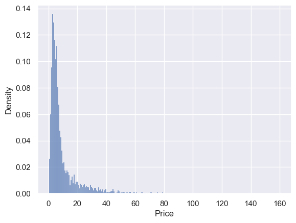

```python
sns.histplot(data=df,x='Price',stat='density')
plt.show()
```

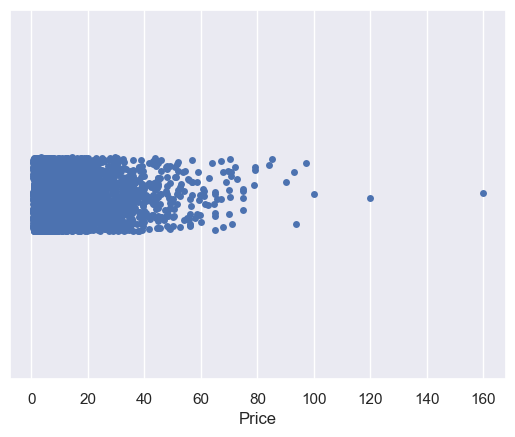

```python
sns.stripplot(data=df, x='Price');
```

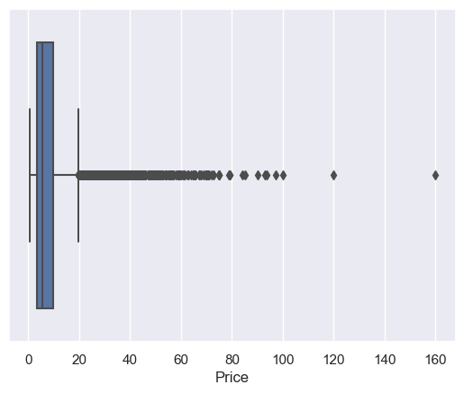

```python
sns.boxplot(data=df,x='Price')
plt.show()
```

It's clear that Price is heavily right skewed so we can't just use the mean to fill the nulls.

I'll check out the Mean, Median and Mode to see how they compare

```python
mean = df['Price'].mean()
median = df['Price'].median()
mode = df['Price'].mode()

print('Mean: ', mean)
print('Median: ', median)
print('Mode: ', mode)
```

```
Mean:  9.47946835022429
Median:  5.64
Mode:  0   4.50
Name: Price, dtype: float64
```

```python
#Sanity checking to make sure I know what the min is
df[df['Price'] == min(df['Price'])]
```

|  | Location | Year | Kilometers_Driven | Fuel_Type | Transmission | Owner_Type | Seats | New_Price | Price | Car_Make | Mileage | Engine | Power |
| --- | --- | --- | --- | --- | --- | --- | --- | --- | --- | --- | --- | --- | --- |
| 1713 | Pune | 2011 | 65000 | Petrol | Manual | Second | 4.00 | 7.63 | 0.44 | TATA | 61.16 | 624.00 | 35.00 |

```python
df['Price'] = df['Price'].fillna(df['Price'].median())
```

```python
df.loc[df['Price'].isnull()==True]
```

|  | Location | Year | Kilometers_Driven | Fuel_Type | Transmission | Owner_Type | Seats | New_Price | Price | Car_Make | Mileage | Engine | Power |
| --- | --- | --- | --- | --- | --- | --- | --- | --- | --- | --- | --- | --- | --- |

```python
df.head()
```

|  | Location | Year | Kilometers_Driven | Fuel_Type | Transmission | Owner_Type | Seats | New_Price | Price | Car_Make | Mileage | Engine | Power |
| --- | --- | --- | --- | --- | --- | --- | --- | --- | --- | --- | --- | --- | --- |
| 0 | Mumbai | 2010 | 72000 | CNG | Manual | First | 5.00 | 5.51 | 1.75 | MARUTI | 75.14 | 998.00 | 58.16 |
| 1 | Pune | 2015 | 41000 | Diesel | Manual | First | 5.00 | 16.06 | 12.50 | HYUNDAI | 46.27 | 1582.00 | 126.20 |
| 2 | Chennai | 2011 | 46000 | Petrol | Manual | First | 5.00 | 8.61 | 4.50 | HONDA | 42.81 | 1199.00 | 88.70 |
| 3 | Chennai | 2012 | 87000 | Diesel | Manual | First | 7.00 | 11.27 | 6.00 | MARUTI | 48.85 | 1248.00 | 88.76 |
| 4 | Coimbatore | 2013 | 40670 | Diesel | Automatic | Second | 5.00 | 53.14 | 17.74 | AUDI | 35.75 | 1968.00 | 140.80 |

```python
from sklearn.preprocessing import StandardScaler

scaler = StandardScaler()
df['Price_zscore'] = scaler.fit_transform(df[['Price']])
df['NewPrice_zscore'] = scaler.fit_transform(df[['New_Price']])
```

```python
df.head()
```

|  | Location | Year | Kilometers_Driven | Fuel_Type | Transmission | Owner_Type | Seats | New_Price | Price | Car_Make | Mileage | Engine | Power | Price_zscore | NewPrice_zscore |
| --- | --- | --- | --- | --- | --- | --- | --- | --- | --- | --- | --- | --- | --- | --- | --- |
| 0 | Mumbai | 2010 | 72000 | CNG | Manual | First | 5.00 | 5.51 | 1.75 | MARUTI | 75.14 | 998.00 | 58.16 | -0.69 | -0.65 |
| 1 | Pune | 2015 | 41000 | Diesel | Manual | First | 5.00 | 16.06 | 12.50 | HYUNDAI | 46.27 | 1582.00 | 126.20 | 0.36 | -0.22 |
| 2 | Chennai | 2011 | 46000 | Petrol | Manual | First | 5.00 | 8.61 | 4.50 | HONDA | 42.81 | 1199.00 | 88.70 | -0.42 | -0.52 |
| 3 | Chennai | 2012 | 87000 | Diesel | Manual | First | 7.00 | 11.27 | 6.00 | MARUTI | 48.85 | 1248.00 | 88.76 | -0.27 | -0.41 |
| 4 | Coimbatore | 2013 | 40670 | Diesel | Automatic | Second | 5.00 | 53.14 | 17.74 | AUDI | 35.75 | 1968.00 | 140.80 | 0.87 | 1.31 |

```python
df[(df['Price_zscore']>3) | (df['Price_zscore']< -3)]
```

|  | Location | Year | Kilometers_Driven | Fuel_Type | Transmission | Owner_Type | Seats | New_Price | Price | Car_Make | Mileage | Engine | Power | Price_zscore | NewPrice_zscore |
| --- | --- | --- | --- | --- | --- | --- | --- | --- | --- | --- | --- | --- | --- | --- | --- |
| 134 | Kolkata | 2017 | 13372 | Petrol | Automatic | First | 2.00 | 95.04 | 54.00 | MERCEDES-BENZ | 44.69 | 2996.00 | 362.07 | 4.39 | 3.04 |
| 168 | Mumbai | 2015 | 41000 | Diesel | Automatic | First | 5.00 | 55.07 | 45.00 | BMW | 35.99 | 2993.00 | 258.00 | 3.51 | 1.39 |
| 172 | Bangalore | 2016 | 44414 | Diesel | Automatic | First | 5.00 | 63.80 | 42.50 | MERCEDES-BENZ | 42.10 | 2143.00 | 170.00 | 3.27 | 1.75 |
| 191 | Coimbatore | 2018 | 36091 | Diesel | Automatic | First | 5.00 | 120.00 | 55.76 | LAND | 29.87 | 2179.00 | 187.70 | 4.56 | 4.07 |
| 216 | Delhi | 2012 | 56000 | Diesel | Automatic | First | 5.00 | 53.14 | 45.00 | AUDI | 27.76 | 2967.00 | 246.70 | 3.51 | 1.31 |
| ... | ... | ... | ... | ... | ... | ... | ... | ... | ... | ... | ... | ... | ... | ... | ... |
| 5900 | Coimbatore | 2017 | 50794 | Diesel | Automatic | First | 5.00 | 63.80 | 43.30 | MERCEDES-BENZ | 42.10 | 2143.00 | 170.00 | 3.35 | 1.75 |
| 5919 | Hyderabad | 2015 | 8000 | Petrol | Automatic | First | 2.00 | 69.67 | 100.00 | JAGUAR | 29.40 | 5000.00 | 488.10 | 8.86 | 1.99 |
| 5927 | Coimbatore | 2018 | 29091 | Diesel | Automatic | First | 5.00 | 53.14 | 45.52 | AUDI | 31.10 | 2967.00 | 241.40 | 3.57 | 1.31 |
| 5946 | Bangalore | 2016 | 16000 | Diesel | Automatic | First | 5.00 | 67.87 | 48.00 | BMW | 34.55 | 2993.00 | 258.00 | 3.81 | 1.92 |
| 6008 | Hyderabad | 2013 | 40000 | Diesel | Automatic | Second | 4.00 | 136.00 | 45.00 | PORSCHE | 41.99 | 2967.00 | 300.00 | 3.51 | 4.73 |

178 rows × 15 columns

```python
df[(df['NewPrice_zscore']>3) | (df['NewPrice_zscore']< -3)]
```

|  | Location | Year | Kilometers_Driven | Fuel_Type | Transmission | Owner_Type | Seats | New_Price | Price | Car_Make | Mileage | Engine | Power | Price_zscore | NewPrice_zscore |
| --- | --- | --- | --- | --- | --- | --- | --- | --- | --- | --- | --- | --- | --- | --- | --- |
| 13 | Delhi | 2014 | 72000 | Diesel | Automatic | First | 5.00 | 120.00 | 27.00 | LAND | 29.87 | 2179.00 | 187.70 | 1.77 | 4.07 |
| 14 | Pune | 2012 | 85000 | Diesel | Automatic | Second | 5.00 | 120.00 | 17.50 | LAND | 0.00 | 2179.00 | 115.00 | 0.84 | 4.07 |
| 70 | Mumbai | 2008 | 73000 | Petrol | Automatic | First | 5.00 | 136.00 | 14.50 | PORSCHE | 19.99 | 4806.00 | 500.00 | 0.55 | 4.73 |
| 134 | Kolkata | 2017 | 13372 | Petrol | Automatic | First | 2.00 | 95.04 | 54.00 | MERCEDES-BENZ | 44.69 | 2996.00 | 362.07 | 4.39 | 3.04 |
| 148 | Mumbai | 2013 | 23000 | Petrol | Automatic | First | 4.00 | 128.00 | 37.00 | AUDI | 25.99 | 2894.00 | 444.00 | 2.74 | 4.40 |
| ... | ... | ... | ... | ... | ... | ... | ... | ... | ... | ... | ... | ... | ... | ... | ... |
| 6857 | Mumbai | 2011 | 87000 | Diesel | Automatic | First | 5.00 | 120.00 | 5.64 | LAND | 0.00 | 2179.00 | 115.00 | -0.31 | 4.07 |
| 6960 | Coimbatore | 2018 | 18338 | Petrol | Automatic | First | 2.00 | 106.00 | 5.64 | MERCEDES-BENZ | 44.69 | 2996.00 | 362.07 | -0.31 | 3.49 |
| 7156 | Kochi | 2013 | 86107 | Petrol | Automatic | First | 5.00 | 158.00 | 5.64 | BMW | 19.88 | 2979.00 | 321.00 | -0.31 | 5.64 |
| 7157 | Hyderabad | 2015 | 49000 | Diesel | Automatic | Second | 5.00 | 120.00 | 5.64 | LAND | 29.87 | 2179.00 | 187.70 | -0.31 | 4.07 |
| 7198 | Hyderabad | 2012 | 147202 | Diesel | Automatic | First | 7.00 | 120.00 | 5.64 | LAND | 27.76 | 2993.00 | 241.60 | -0.31 | 4.07 |

158 rows × 15 columns

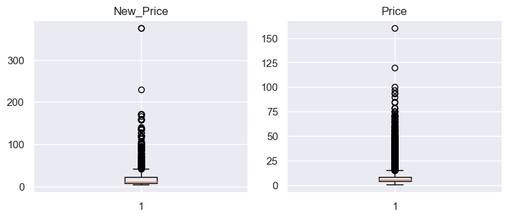

```python
numeric_columns = ['New_Price', 'Price']
plt.figure(figsize=(15, 12))

for i, variable in enumerate(numeric_columns):
    plt.subplot(4, 4, i + 1)
    plt.boxplot(df[variable], whis=1.5)
    plt.tight_layout()
    plt.title(variable)

plt.show()
```

```python
# to find the 25th percentile and 75th percentile for the numerical columns.
Q1 = df[numeric_columns].quantile(0.25)
Q3 = df[numeric_columns].quantile(0.75)

IQR = Q3 - Q1                   #Inter Quantile Range (75th percentile - 25th percentile)

lower_whisker = Q1 - 1.5*IQR    #Finding lower and upper bounds for all values. All values outside these bounds are outliers
upper_whisker = Q3 + 1.5*IQR

# Percentage of outliers in each column
((df[numeric_columns] < lower_whisker) | (df[numeric_columns] > upper_whisker)).sum()/df.shape[0]*100
```

```
New_Price   15.14
Price       13.54
dtype: float64
```